# 30th July

Anna Hutchinson

### Simulations

I simulate GWAS results for 114,310 SNPs on chromosome 22, including 37 CVs.

I consider 3 use cases:

- TFBS (causals +/- 5bp) –> 38 SNPs
- ATAC/ChIP-seq peaks (causals +/- 250bp) –> 124 SNPs
- Open chromatin regions (causals +/- 1000bp) –> 366 SNPs

[I have the code ready, but need to finalise the functional cFDR function first].

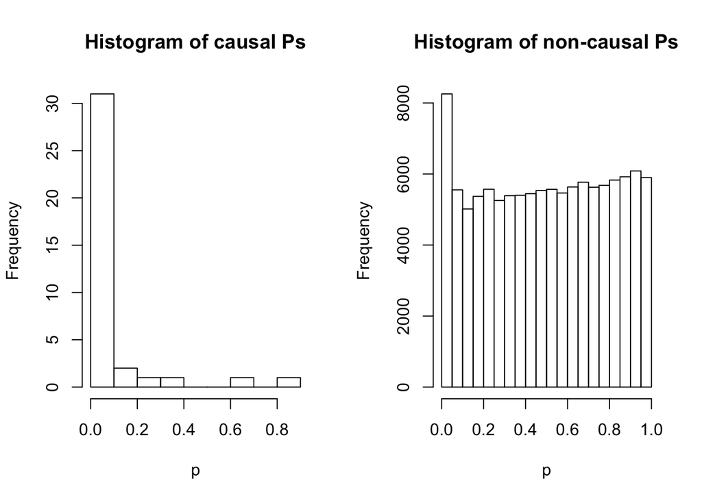

#### Independent uniform

I first consider simulations where $q$ is sampled from a uniform distribution, so that I can compare results to those using empirical cFDR.

Sample $q$ from `w*exp(-rexp(x, rate = 1)) + (1-w)*exp(-rexp(x, rate = 1/2))` where `w <- sample(seq(0.3, 0.7, 0.1), 1)`.

I need to ensure that the correlation between p and q is positive (for both the full dataset and the independent subset).

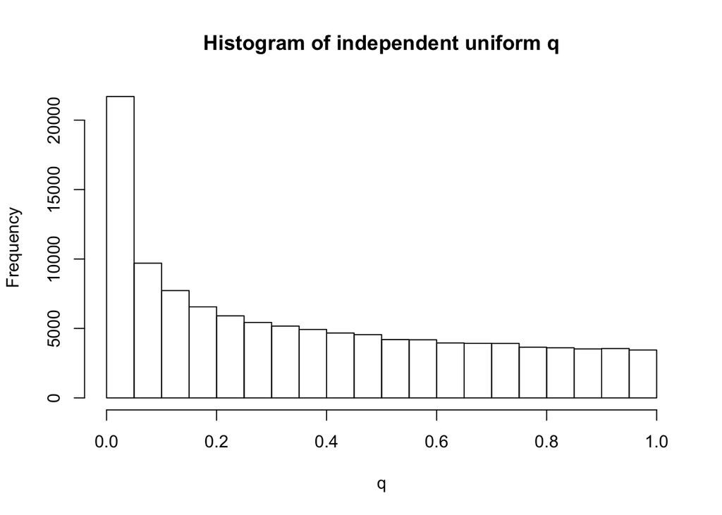

#### Independent mixture beta $q$

Sample $q$ from `0.99*rbeta(x, shape1 = 30, shape2 = 0.5) + 0.01*rbeta(x, shape1 = 0.5, shape2 = 30)`.

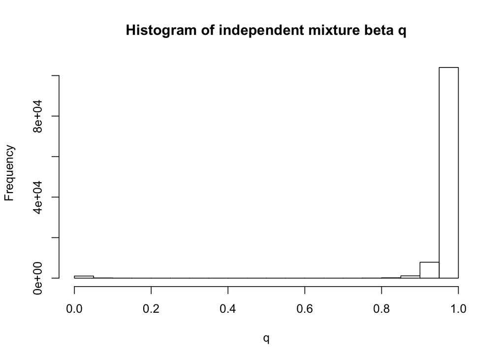

#### Dependent mixture beta $q$

Sample $q$ at null SNPs from `0.99*rbeta(x, shape1 = 30, shape2 = 0.5) + 0.01*rbeta(x, shape1 = 0.5, shape2 = 30)` and $q$ at “causals” from `0.01*rbeta(x, shape1 = 30, shape2 = 0.5) + 0.99*rbeta(x, shape1 = 0.5, shape2 = 30)` where “causals” are chosen as those SNPs defined in our 3 use cases above.

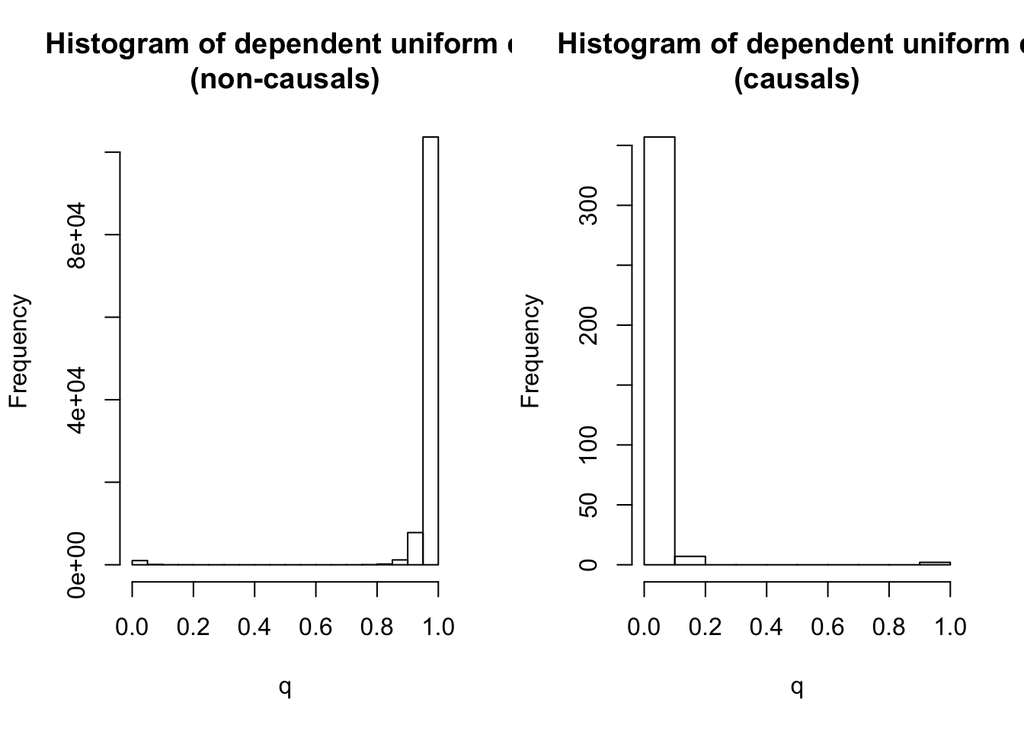

### Comparing to James

Note that in the independent simulations, the correlation between p and q is close to 0. Infact, it may be (just) $>0$ in the whole dataset but (just) $<0$ in the independent subset of SNPs. This is what was responsible for the different colouring between mine and James’ method. I amend the cFDR function to return an error if the sign of the correlation is different between the whole dataset and the independent subset.

I compare the results from James’ KDE method (`vly()`), James’ empirical method (`vl()`) and my method for independent uniform $q$.

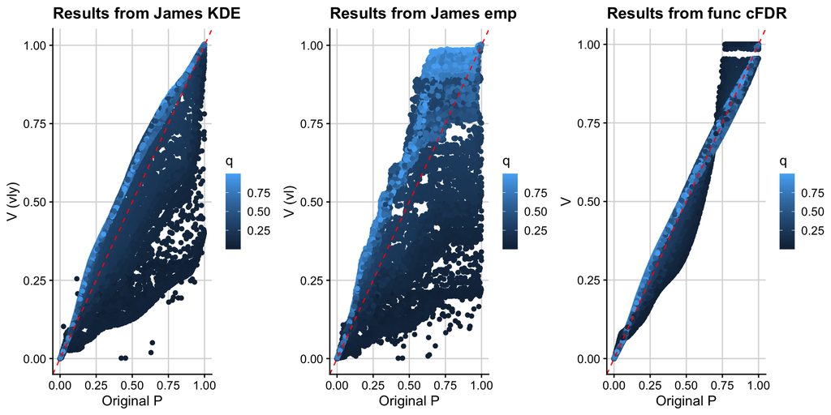

Since James’ KDE method is most similar to mine, I directly compare the results from functional cFDR to James’ KDE cFDR (`vly()`). For high $q$, James’ method increases the $p$ values more and for low $q$, James’ method decreases the $p$ values (a lot) more. Also need to investigate the gap in points..

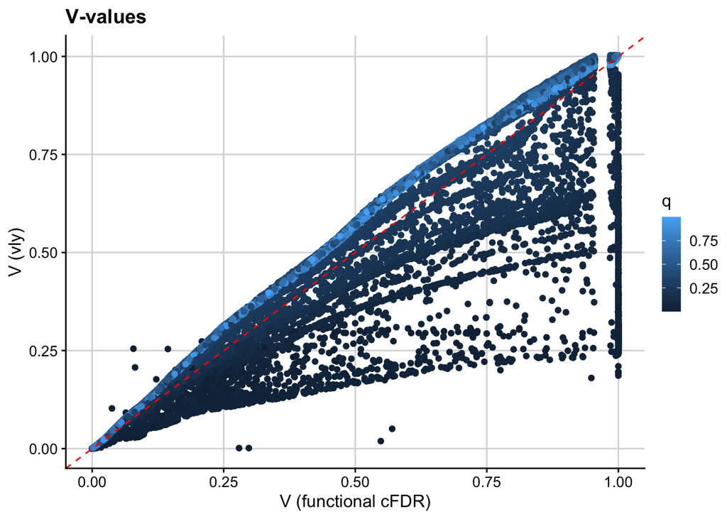

I step through mine and James’ KDE code to see what may be causing this descrepancy.

Firstly, both methods estimate the bivariate density.

- `vly()`: `kde2d(zp[sub], zq[sub], n=200, lims=c(0,12,0,12))`
- `cFDR()`: `kde2d(c(zp, -zp), c(q, q), n = c(300, 500), lims = lims)`

I.e. we use a folding method so that the KDE doesn’t have to “come down” at `p=1` (`zp=0`). [Note, results similar if I use `n=200` and `lims=c(0,12,0,12)` in my method].

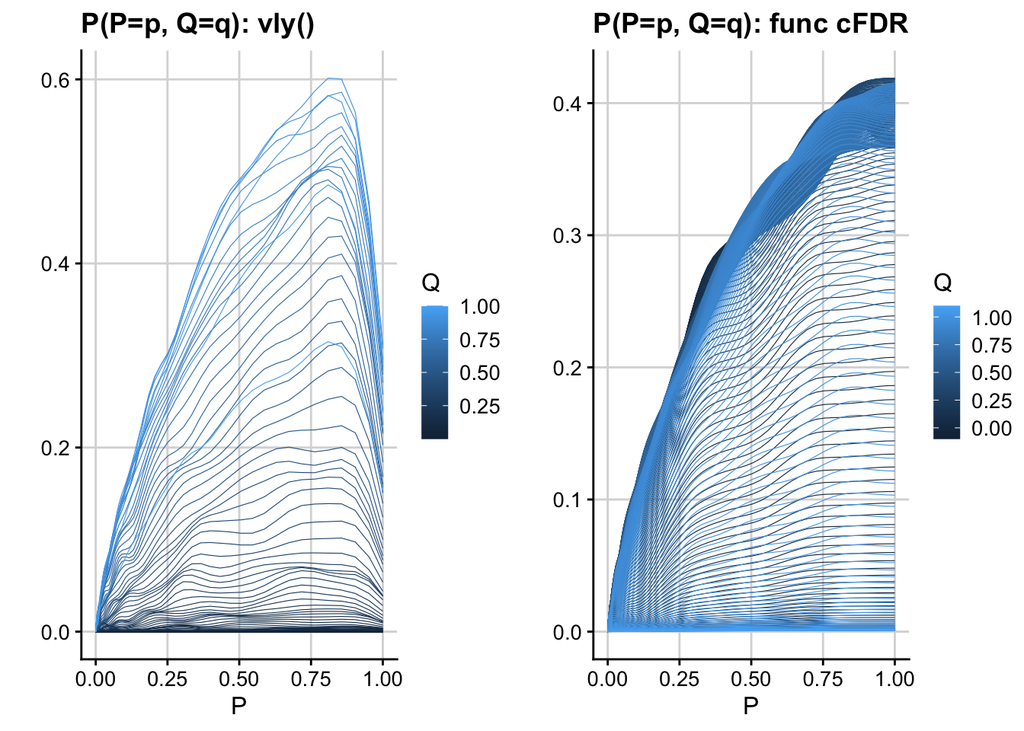

I then incorporate the adjustment directly (so that various terms cancel). Whereas James incorporates the adjustment seperately. My L curves are defined as the contours of the cFDR curves, whereas James’ are approximated using `approx(cfx,xtest,ccut/correct[i],rule=2,method="const",f=1)$y` where `correct[i]` incorporates the adjustment.

James’ L curves are defined on [0,1] whereas mine are defined on [lims[3], lims[4]].

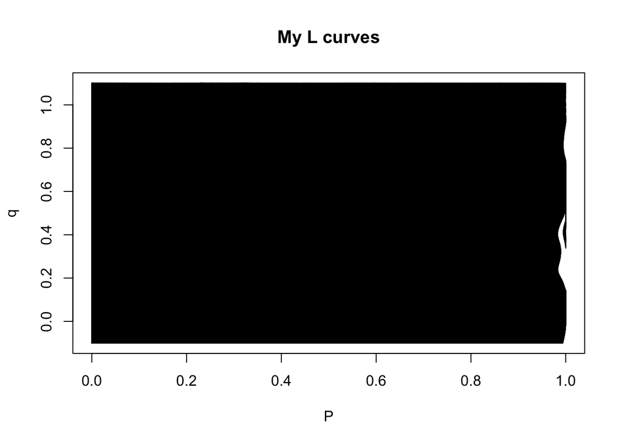

### Summarising annotation data

- PCAmix: Current method, but possible non-monotonicity problem that orthogonal rotations (e.g. varimax) don’t seem to fix.
- Non-negative matrix factorisation: but the following annotations have negative entries `MAF_Adj_Predicted_Allele_Age; MAF_Adj_LLD_AFR; MAF_Adj_ASMC` and I can’t see how I can easily make them non-negative.

### To do

- Finalise code.
- Run simulations.
- Run on Asthma data (once I’ve sorted out some dimensionality reduction for the annotation data).
- Make R package.